# Calculating fractal dimentions

D. Emin

December 19, 2018

## Summary

> - The scale at which particular phenomenon is observed affects the strength of the pheonomenon
> - Computational procedure to calculate the fractal dimentionality of SIF~LAI relationship is presented
> - $R{^2}$ for linear model SIF~LAI and the squared Pearson’s correlation coefficient for SIF~LAI for range of scales are calculated

## Scale

Choosing the appropriate scale at which to study a particular phenomenon is important. The shape or the strenght of a relationship beteween two environmental variables might differ when observed at two different scales. In this respect, in geography, the term *operational scale* defines the scale at which a particular spatially continuos phenomenon is most relevant (in other words - most promenon). The *cartographic scale* of a particular research (coloqualy - the spatial resolution) should be governed by the scale at which the phenomenon of interest is most relevant, e.g. resolution should be chosen to match as close as possible the operational scale of a phenomenon.

Identifying the appropraite operational scale can be done empirically by comparing some goodness-of-fit statistics across the possible scales. Here, we will describe the computational procedure performed to find two goodness-of-fit statistics for range of spatial resolutions. First, the raster files from HyPlant will be gradually degraded until spatial resolution of 300m is reached. Then the Pearson’s correlation matrix and the goodness-of-fit of a linear model ($R^{2}$) will be calculated for each scale. Finally, the correlation coefficient will be plotted against the cartographic scale.

## Calculation procedure

### Input data

We will use the 2016 raster stack with outliers removed (correction, SIF.ratio outliers are still there, and will be removed at the next step). The raster itself contains three SIF estimates (760, 687, and Ratio) and three canopy structure estimates (Leaf Area Index, Leaf chlorophyll Content, Canopy chlorophyll Content).

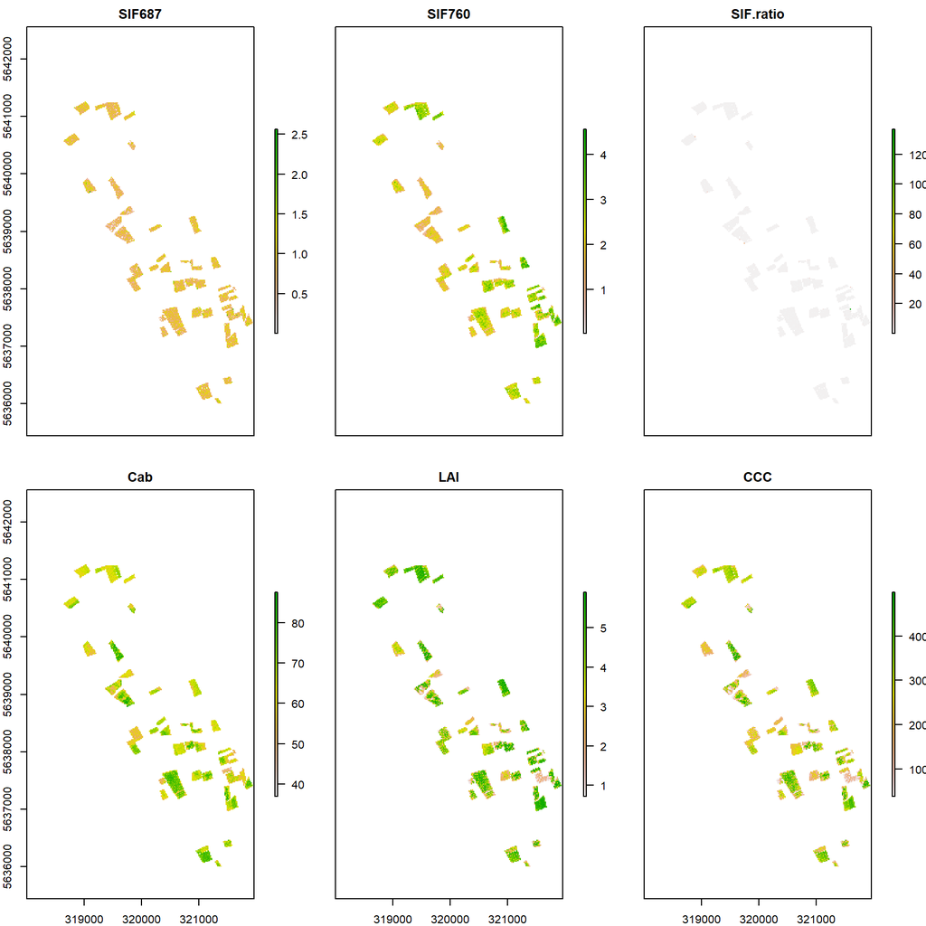

Figure 1. Input rasters

```r
plot(r, xlim = c(318000, 322000), ylim = c(5636000,5642000))
```

### Degrading original raster to lower resolution

First, re-scale the rasters by calculating mean value over a nxn meters window for n between 3 and 300.

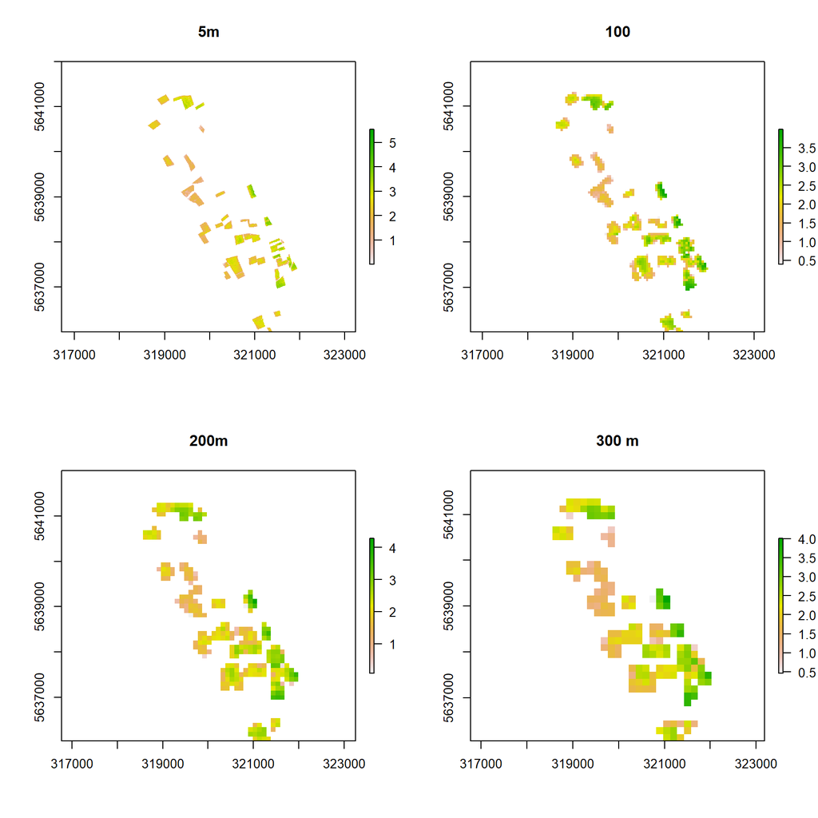

Figure 2. Rescaled rasters

```r
# Aggregating rasters from 3x3 to 300x300 (fact = 2:151)
#                                       # aggregate counts the center pixel as start.
#                                       # for a 3x3 window fact = 2
r.list <- list()                        # for a 5x5 window fact = 3
for (i in c(2:151)) {                   # for a 7x7 window fact = 4
r.list[[i-1]] <- aggregate(r,fact = i)  # for a nxn window fact = (n + 1)/2
}

# plot
res = c(2,50,100,150)
main = c("5m", "100", "200m", "300 m")
par(mfrow=c(2,2))

for(i in c(1:4)){
    plot(r.list[[res[i]]]$SIF760,main= main[i], xlim = c(318000, 322000), ylim = c(5636000,5642000))
}
```

Move away from list of rasters and use a list of data frames.

```r
# convert to a data frame
df.list <- lapply(r.list, extract, y = sb.map, df = T)

# further corrections
df.list <- lapply(df.list, function(x) x <- x[x$SIF.ratio < 2,])
df.list <- lapply(df.list, na.omit)
```

### Calculating Person’s $\rho$

Since linear model and correlation statistics are sample size sensitive and rescaled rasters have progressively smaller number of pixels, we cannot simply compare the statistics for each scale based on the entire data set. Instead, We need to pool an equal ammount of random pixels from each raster and use that sample to compute the statistics of interest. To eliminate uncertainty due to the selection of a random sample, i.e. to eliminate sampling bias, we will repeat the correlation matrix number of times, each time with a different randomly selected sample. The correlation coefficient will then be taken as the average from all repetitions. In essence, we will include a bootstraping procedure to find Pearson’s correlation coefficient.

Bellow is the code to perform the bootstrap procedure. Notice that at the final step of calculation we squared the Person’s correlation coefficient. This was done in order to have only positive values and will come handy later when we plot the results.

```r
# bootstraping the correlation matrix

# a function to compute the mean correlation matrix
# of "n" bootstrap replicates
# using a sample size = "smpl" with replacement

mean.cor <- function(input,smpl,n) {
    l <- list()
    for (i in c(1:n)) {
        l[[i]] <- cor(input[sample(nrow(input), smpl, replace = TRUE),], use = "complete")
    }
    cr <- Reduce("+", l)/n
    return(cr)
}

# apply the function to the entire list of data frames
cor.list <- lapply(df.list, mean.cor, smpl= 100, n = 1000)

# compute the R2 as the square of the Pearsons correlation coefficient
r2.list <- lapply(cor.list, function(x) a<-x*x)

# view
knitr::kable(r2.list[[1]], caption = "Table 1. Correlation matrix for 3x3 m resolution.")
```

Table 1. Correlation matrix for 3x3 m resolution.

|  | ID | SIF687 | SIF760 | SIF.ratio | Cab | LAI | CCC |
| --- | --- | --- | --- | --- | --- | --- | --- |
| ID | 1.0000000 | 0.0095295 | 0.0958922 | 0.0394556 | 0.0336607 | 0.0317005 | 0.0414019 |
| SIF687 | 0.0095295 | 1.0000000 | 0.2185271 | 0.0108352 | 0.0383206 | 0.1039720 | 0.0903102 |
| SIF760 | 0.0958922 | 0.2185271 | 1.0000000 | 0.4502656 | 0.0444656 | 0.3005598 | 0.2400509 |
| SIF.ratio | 0.0394556 | 0.0108352 | 0.4502656 | 1.0000000 | 0.0216016 | 0.1172007 | 0.0966584 |
| Cab | 0.0336607 | 0.0383206 | 0.0444656 | 0.0216016 | 1.0000000 | 0.3048121 | 0.5485688 |
| LAI | 0.0317005 | 0.1039720 | 0.3005598 | 0.1172007 | 0.3048121 | 1.0000000 | 0.9296228 |
| CCC | 0.0414019 | 0.0903102 | 0.2400509 | 0.0966584 | 0.5485688 | 0.9296228 | 1.0000000 |

Above is the correlation matrix for 3m resolution. We have a list containing 150 such correlation matrices. Now, we need to restructure this list of correlation tables into a data frame of Person’s correlation coefficients with so many variables as the number of unique pairs ($\binom{6}{2} = 15$) and so many observation as the number of resolutions ($150$).

```r
# write down each unique variable pair
pairs <- c("Resolution", "SIF687~SIF760", "SIF687~SIF.Ratio", "SIF687~Cab",
           "SIF687~LAI", "SIF687~CCC", "SIF760~SIF.Ratio", "SIF760~Cab",
           "SIF760~LAI", "SIF760~CCC", "SIF.Ratio~Cab", "SIF.Ratio~LAI",
           "SIF.Ratio~CCC", "Cab~LAI", "Cab~CCC", "LAI~CCC")

# unlist the final list by R2 for each variable pair
fractal.df <- data.frame(x.vect = seq(3,301, by = 2))
for (i in c(2:6)){
    for (j in c(1:c(7-i))){
        fractal.df <- cbind(fractal.df, unlist(lapply(r2.list, '[[', i,i+j)))
    }

}

# rename the final df
names(fractal.df) <- pairs

# View
knitr::kable(head(fractal.df[,c(1:7)]), caption = "Table 2. Pearson's correlation coefficient for each raster pair for range of spatial resolutions.")
```

| Resolution | SIF687~SIF760 | SIF687~SIF.Ratio | SIF687~Cab | SIF687~LAI | SIF687~CCC | SIF760~SIF.Ratio |
| --- | --- | --- | --- | --- | --- | --- |
| 3 | 0.2185271 | 0.0108352 | 0.0383206 | 0.1039720 | 0.0903102 | 0.4502656 |
| 5 | 0.2934819 | 0.0076158 | 0.0534967 | 0.1426277 | 0.1241223 | 0.5096759 |
| 7 | 0.3294939 | 0.0331968 | 0.0598202 | 0.1660171 | 0.1426774 | 0.5275541 |
| 9 | 0.3438385 | 0.0515076 | 0.0629634 | 0.1821328 | 0.1562917 | 0.5405678 |
| 11 | 0.3576665 | 0.0764591 | 0.0634066 | 0.1875343 | 0.1597199 | 0.5391010 |
| 13 | 0.3543929 | 0.0782821 | 0.0645838 | 0.1923056 | 0.1635991 | 0.5355844 |

And now plot the squared Pearson’s correlation coeeficient against scale to see how various relationships respond to the scale at which they are being observed.

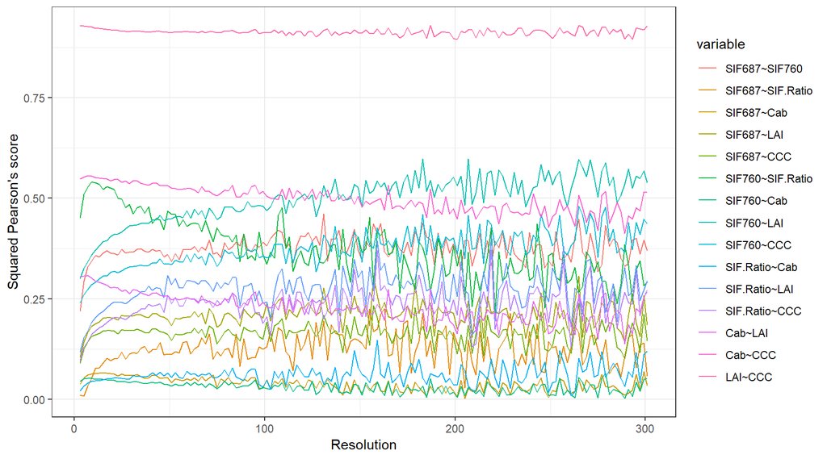

Figure 3. Squared Pearson’s correlation coefficient for all variable pairs for range of aggregation levels (spatial resolutions).

```r
# plot all
mel.df <- reshape::melt(fractal.df, id = "Resolution")

library(ggplot2)
ggplot(mel.df) +
    geom_line(aes(x = Resolution, y = value, color = variable)) +
    theme_bw() +
    ylab("Squared Pearson's score")
```

### Calculating Linear model $R^{2}$

Bellow is the procedure to calculate a linear model for each relevant SIF - canopy structure pair for each resolution and extract the $R^2$ value. One addition to the previos example is the calculation of new SIF indices. A description of those indices can be found in another chapter.

```r
# lm procedure for a df

for (i in seq_along(df.list)) {
    data <- df.list[[i]]
    # select and calculate additional SIF estimates
    lm.inputs <- data %>%
        select(SIF687, SIF760, SIF.ratio, LAI, Cab, CCC) %>%
        filter(complete.cases(.),
               SIF687 > 0,
               SIF760 >0,
               SIF.ratio < 2) %>%
        mutate(SIFdiff = SIF760 - SIF687,
               ndSIF1 = (SIF760 - SIF687) / (SIF760 + SIF687),
               ndSIF2 = (SIF760 - SIF687) / SIF760,
               ndSIF3 = (SIF760 - SIF687) / SIF687,
               SIFtot = SIF760 + SIF687,
               SIFi = SIFtot * SIF.ratio  )  %>%
        sample_frac(size = 0.01)


    # perform PCA
    pca <- prcomp(as.data.frame(lm.inputs[,c(1,2)]))
    lm.inputs <- lm.inputs %>% mutate(PC1 = pca$x[,1],
                              PC2 = pca$x[,2])

    # perform linear model for all combinations
    independents <- names(select(lm.inputs,4:9)) # select  independent variables
    dependents <- names(select(lm.inputs,c(1:3,10:17)))   # and dependent variables
    lm.list <- list()  # empty list to store the linear model

    for (i in seq_along(dependents)){
        for (j in seq_along(independents)){
            eq <- paste(dependents[i],"~", independents[j], sep = "")
            lm.list[[eq]] <- lm(as.formula(eq), data = lm.inputs)
        }
    }


    # extract r2 from each linear model
    results.r2 <- cbind(names(lm.list),lapply(lm.list, function(x) summary(x)$adj.r.squared), deparse.level = 0)

}
```

[figure not shown]

Figure 4. Coefficient of determination from a linear model for all SIF estimates predicted by all structural parameters for range of aggregation levels (spatial resolutions).

```r
# plot all
mel.df <- reshape2::melt(results.r2, id = "Resolution")

library(ggplot2)
ggplot(mel.df) +
    geom_line(aes(x = Resolution, y = value, color = variable)) +
    theme_bw() +
    ylab(expression("Coefficient of determination (R^2)"))
```